# Roméo et Juliette

Drame lyrique in fünf Akten (1867)

Musik von Charles Gounod  
Text von Jules Barbier und Michel Carré nach William Shakespeare

[Tickets](https://staatsoper-berlin.eventim-inhouse.de/webshop/webticket/shop?language=de&event=18203)

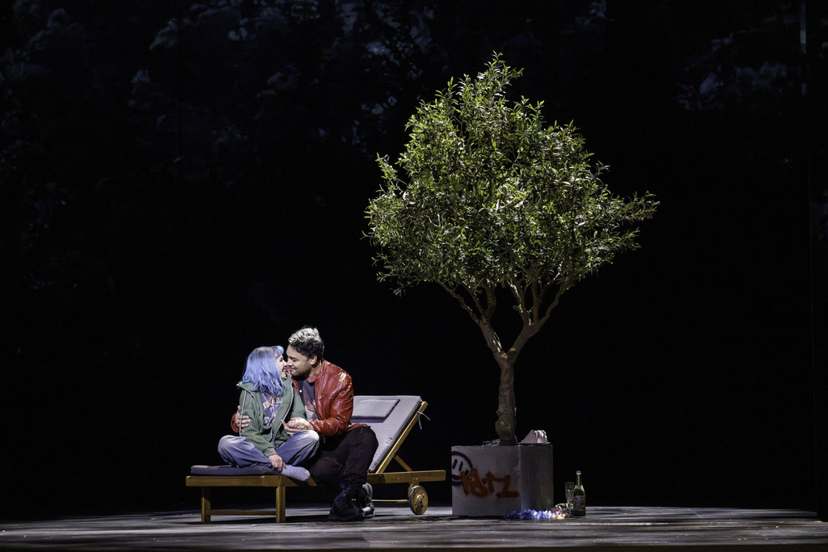

Sie sind das berühmteste Liebespaar der Welt: Wie ein Mythos ziehen sich Romeo und Julia aus Shakespeares gleichnamigem Drama seit dessen Uraufführung im Jahr 1597 durch die Weltliteratur. Unter den zahlreichen Vertonungen des Stoffes zählt Charles Gounods *Roméo et Juliette* zu den meistgespielten. Bereits die Uraufführung im Rahmen der Weltausstellung 1867 wurde zu einem triumphalen Erfolg. Gounod spürt insbesondere dem Gefühlsleben der titelgebenden Liebenden feinsinnig nach, für die er gleich vier Liebesduette komponierte. Gleichzeitig gibt er auch dem gesellschaftlichen Kontext ihrer verbotenen Liebe in Form von klanggewaltigen Chortableaus und einer großen Kampfszene der verfeindeten Familien Raum. Die Regisseurin Mariame Clément legt in ihrer Inszenierung den Fokus auf die Jugend der Titelfiguren und zeigt sie nicht als überhöhten Idealtypus eines Paars, sondern vielmehr als junge Menschen von heute, die gegen alle Widerstände zueinander finden.

Familienvorstellung

Sonntag, 24. November 2024  
18.00 Uhr

[Staatsoper Unter den Linden](https://www.staatsoper-berlin.de/de/ihr-besuch/anfahrt/staatsoper-unter-den-linden.35/)

[Tickets](https://staatsoper-berlin.eventim-inhouse.de/webshop/webticket/shop?language=de&event=18203)

Dauer: ca. 3:15 h inklusive einer Pause

Sprache: In französischer Sprache mit deutschen und englischen Übertiteln

Altersempfehlung: ab 12 Jahren

Einblick am 4. November 2024  
Vorwort 45 Minuten vor Vorstellungsbeginn im Apollosaal

## Besetzung

- Musikalische Leitung:

  [Stefano Montanari](https://www.staatsoper-berlin.de/de/kuenstler/stefano-montanari.3436/)
- Inszenierung:

  [Mariame Clément](https://www.staatsoper-berlin.de/de/kuenstler/mariame-clement.3437/)
- Bühne, Kostüme:

  [Julia Hansen](https://www.staatsoper-berlin.de/de/kuenstler/julia-hansen.3438/)
- Licht:

  [Ulrik Gad](https://www.staatsoper-berlin.de/de/kuenstler/ulrik-gad.3440/)
- Video:

  [Sébastien Dupouey](https://www.staatsoper-berlin.de/de/kuenstler/sebastien-dupouey.3572/)
- Choreographie:

  [Mathieu Guilhaumon](https://www.staatsoper-berlin.de/de/kuenstler/mathieu-guilhaumon.3439/)
- Stuntkoordination:

  [Ran Arthur Braun](https://www.staatsoper-berlin.de/de/kuenstler/ran-arthur-braun.2820/)
- Einstudierung Chor:

  [Dani Juris](https://www.staatsoper-berlin.de/de/kuenstler/dani-juris.3290/)
- Dramaturgie:

  [Christoph Lang](https://www.staatsoper-berlin.de/de/kuenstler/christoph-lang.2954/)
- Spielleitung:
  - [José Darío Innella](https://www.staatsoper-berlin.de/de/kuenstler/jose-dario-innella.3590/),
  - Tabatha McFadyen
- Juliette:

  [Elsa Dreisig](https://www.staatsoper-berlin.de/de/kuenstler/elsa-dreisig.1128/)
- Gertrude:

  [Marina Prudenskaya](https://www.staatsoper-berlin.de/de/kuenstler/marina-prudenskaya.1105/)
- Tybalt:

  [Johan Krogius](https://www.staatsoper-berlin.de/de/kuenstler/johan-krogius.3030/)
- Pâris:

  [David Oštrek](https://www.staatsoper-berlin.de/de/kuenstler/david-ostrek.1056/)
- Capulet:

  [Arttu Kataja](https://www.staatsoper-berlin.de/de/kuenstler/arttu-kataja.1118/)
- Grégorio:

  [Dionysios Avgerinos](https://www.staatsoper-berlin.de/de/kuenstler/dionysios-avgerinos.3277/)
- Roméo:

  [Petr Nekoranec](https://www.staatsoper-berlin.de/de/kuenstler/petr-nekoranec.3623/)
- Stéphano:

  [Ema Nikolovska](https://www.staatsoper-berlin.de/de/kuenstler/ema-nikolovska.2671/)
- Mercutio:

  [Jaka Mihelač](https://www.staatsoper-berlin.de/de/kuenstler/jaka-mihelac.2236/)
- Benvolio:

  [Andrés Moreno García](https://www.staatsoper-berlin.de/de/kuenstler/andres-moreno-garcia.1512/)
- Frère Laurent:

  [Nicolas Testé](https://www.staatsoper-berlin.de/de/kuenstler/nicolas-teste.3442/)
- Le Duc:

  [Manuel Winckhler](https://www.staatsoper-berlin.de/de/kuenstler/manuel-winckhler.3435/)
- - [Staatsopernchor](https://www.staatsoper-berlin.de/de/kuenstler/staatsopernchor.1020/),
  - [Staatskapelle Berlin](https://www.staatsoper-berlin.de/de/kuenstler/staatskapelle-berlin.1019/)